# analysis_notebook

### Load the Libraries

```
BioPython v1.79
re module v2.2.1
matplotlib v3.4.2
pandas v1.3.3
```

```
Python 3.8.12
```

```
Selected Jupyter core packages...
IPython          : 7.27.0
ipykernel        : 6.4.1
ipywidgets       : 7.6.5
jupyter_client   : 7.0.1
jupyter_core     : 4.8.1
jupyter_server   : 1.4.1
jupyterlab       : 3.1.7
nbclient         : 0.5.3
nbconvert        : 6.1.0
nbformat         : 5.1.3
notebook         : 6.4.3
qtconsole        : 5.1.1
traitlets        : 5.1.0
```

### About GenBank files and how to deal with them

We are dealing with .gb/.gbk files with single records each.

From (https://warwick.ac.uk/fac/sci/moac/people/students/peter_cock/python/genbank/)-

```
Depending on the type of GenBank file(s) you are interested in, they will either contain a single record, or multiple records. You can easily determine this by looking at the raw file - each record will start with a LOCUS line, followed by various other header lines, usually a list of features, the sequence data, and ends with a // line (slash slash).
```

Locations provided by **BioPython** is optimum for python purposes.

- start and end provided by it are 1938 and 3075 respectively (0-based indexing and it assumes that end position is not included),
- while in our actual file it is 1939 and 3075 (1-based indexing and it assumes that both start and end positions are included).

This way we can directly slice seq string using locations provided to obtain the seq for the features of our interest.

1. **The DDBJ/ENA/GenBank Feature Table Definition**: Documentation of features in genbank files. Very good document, must go-through this once.

   Source:
   - (https://www.insdc.org/documents/feature_table.html)
1. **Locus tag:** Locus_tags are identifiers that are systematically applied to every gene in a genome. These tags have become surrogate gene names by the biological community. If two submitters of two different genomes use the same systematic names to describe two very different genes in two very different genomes, it can be very confusing. In order to prevent this from happening INSD has created a registry of locus_tag prefixes. Submitters of eukaryotic and prokaryotic genomes should register their prefix prior to submitting their genome. All components of a project (such as multiple chromosomes or plasmids, etc) should use the same locus_tag prefix.

   Source:
   - (https://www.ncbi.nlm.nih.gov/genomes/locustag/Proposal.pdf)
   - (https://www.ncbi.nlm.nih.gov/genbank/genomesubmit_annotation/#locus_tag)

### Extracting desirable information

Useful videos for the analysis done later-

1. https://www.youtube.com/watch?v=LdQV3cbUwEE&list=PLe1-kjuYBZ05T9iHV_z60B9mpFt201ND5&index=8
2. https://www.youtube.com/watch?v=HP7ThAj_f1E

*Both videos are on Youtube @Bioinformatics Coach*

KeyError resolution -

```
gene_name = gene.qualifiers['gene'][0]
gene_name = gene.qualifiers.get('gene',['unavailable'])[0]
```

*Source*: https://bioinformatics.stackexchange.com/questions/15454/keyerror-when-getting-features-from-a-genbank-file-with-biopython-with-some-acce/15456#15456

NOTE: Our file for Staphylococcus aureus (ATCC® 43300™) (https://genomes.atcc.org/genomes/79691302ed634fef) had only CDS as features. So, a code-block was added to handle all such files which will have only CDS as features instead of the usual both genes and CDS as features.

How to iterate over a given directory: https://stackoverflow.com/questions/10377998/how-can-i-iterate-over-files-in-a-given-directory

```
gram_positive_Enterococcus_faecium.gb
Name: NZ_CP038996, Features count: 5490
gram_positive_Streptococcus_pneumoniae.gb
Name: NZ_CP020549, Features count: 4328
gram_positive_Clostridium_botulinum.gb
Name: NC_009495, Features count: 7379
gram_positive_Staphylococcus_epidermidis.gb
Name: NZ_CP035288, Features count: 4671
gram_positive_Cutibacterium_acnes.gb
Name: NC_021085, Features count: 4889
gram_positive_Corynebacterium_diphtheriae.gb
Name: NZ_CP025209, Features count: 4565
gram_positive_Bacillus_subtilis.gb
Name: NC_000964, Features count: 9074
gram_positive_Listeria_monocytogenes.gb
Name: NC_003210, Features count: 9849
gram_positive_Clostridium_perfringens.gb
Name: NZ_CP075979, Features count: 5954
gram_positive_Staphylococcus_aureus_ATCC_43300_chromosome.gbk
Name: 1, Features count: 2734
gram_positive_Staphylococcus_haemolyticus.gb
Name: NZ_CP013911, Features count: 5041
gram_positive_Bacillus_anthracis.gb
Name: NC_007530, Features count: 11041
```

### Motif analysis

```
{1: -200, 2: -199, 3: -198, 4: -197, 5: -196, 6: -195, 7: -194, 8: -193, 9: -192, 10: -191, 11: -190, 12: -189, 13: -188, 14: -187, 15: -186, 16: -185, 17: -184, 18: -183, 19: -182, 20: -181, 21: -180, 22: -179, 23: -178, 24: -177, 25: -176, 26: -175, 27: -174, 28: -173, 29: -172, 30: -171, 31: -170…
```

How to iterate rows of a dataframe: https://stackoverflow.com/questions/16476924/how-to-iterate-over-rows-in-a-dataframe-in-pandas

```
GBdata_gram_positive_Cutibacterium_acnes.csv
2435
GBdata_gram_positive_Staphylococcus_epidermidis.csv
2325
GBdata_gram_positive_Clostridium_botulinum.csv
3667
GBdata_gram_positive_Staphylococcus_haemolyticus.csv
2509
GBdata_gram_positive_Bacillus_anthracis.csv
5479
GBdata_gram_positive_Staphylococcus_aureus_ATCC_43300_chromosome.csv
2656
GBdata_gram_positive_Streptococcus_pneumoniae.csv
2157
GBdata_gram_positive_Bacillus_subtilis.csv
4536
GBdata_gram_positive_Corynebacterium_diphtheriae.csv
2279
GBdata_gram_positive_Clostridium_perfringens.csv
2954
GBdata_gram_positive_Enterococcus_faecium.csv
2735
GBdata_gram_positive_Listeria_monocytogenes.csv
3055
```

### Visualization

#### Preparing for batch-Visualization

#### Frequency plots

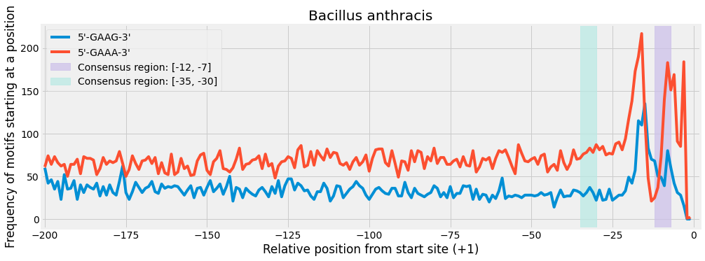

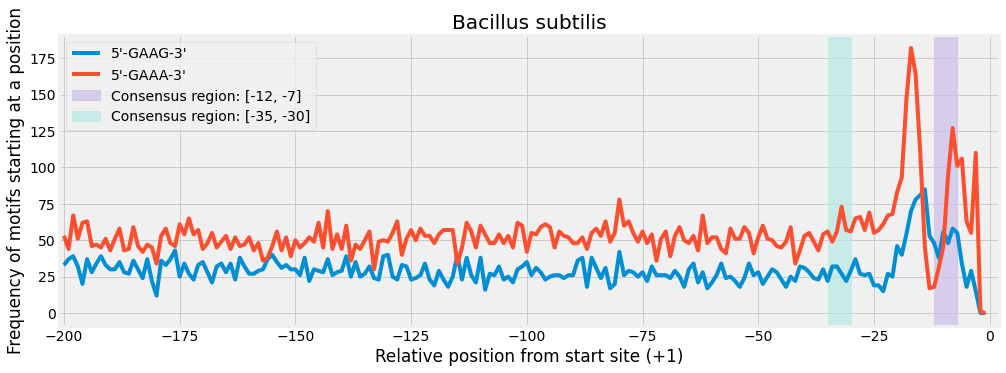

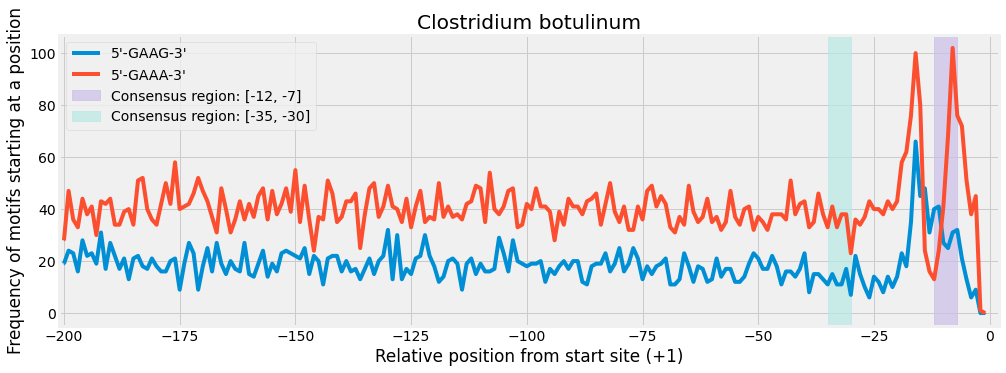

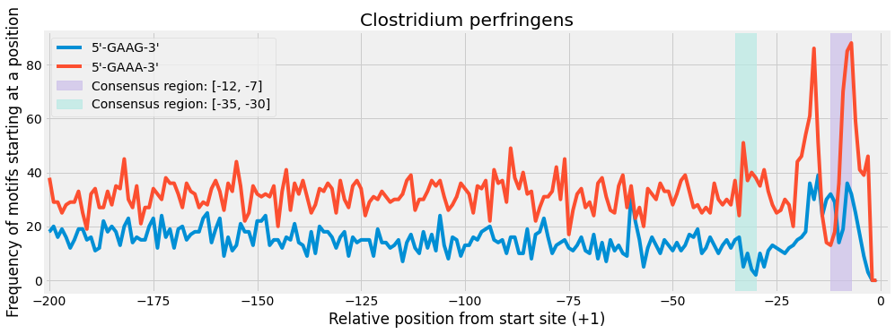

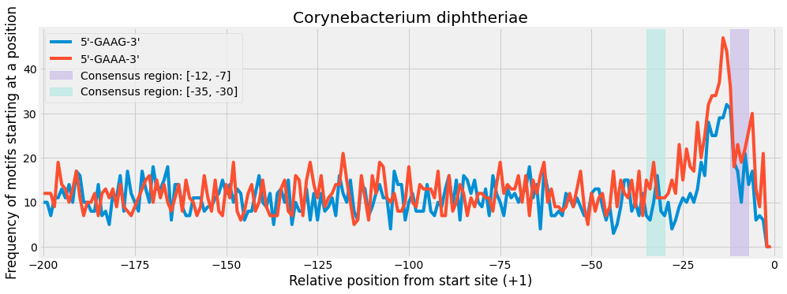

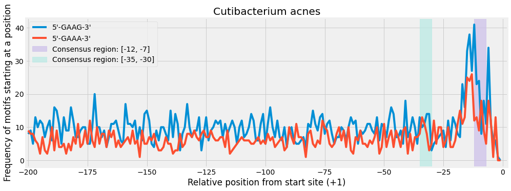

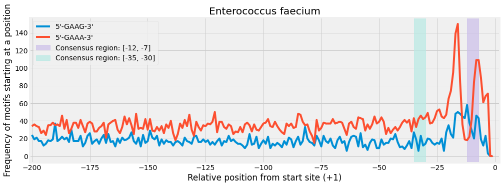

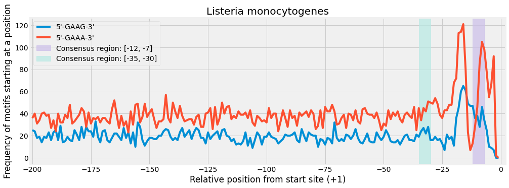

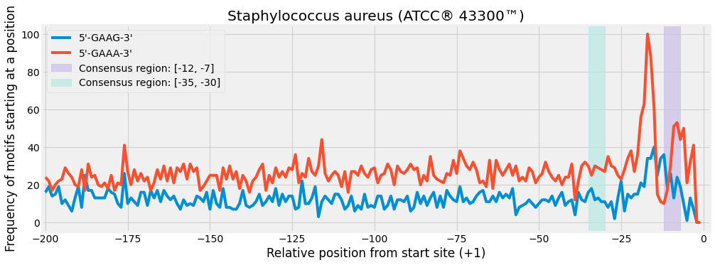

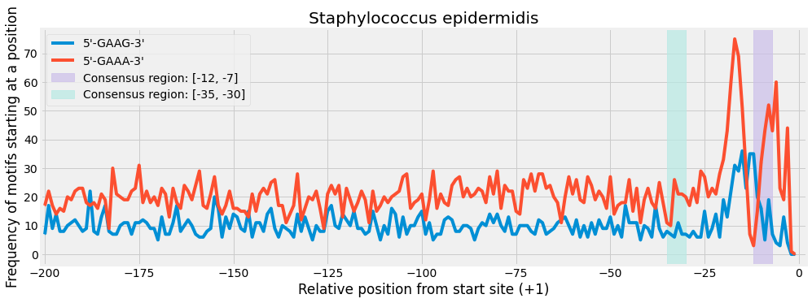

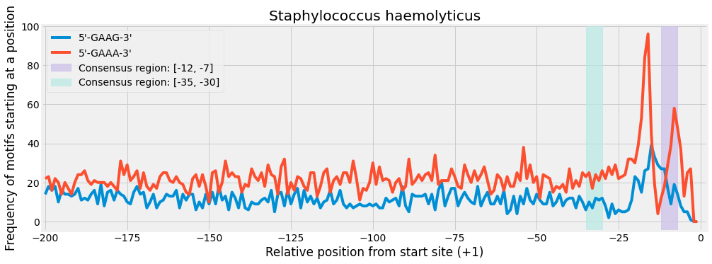

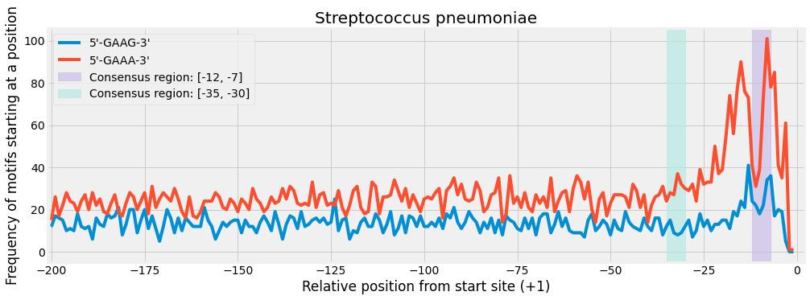

#### Division by summed value normalization: MA_sum- SWAN plots

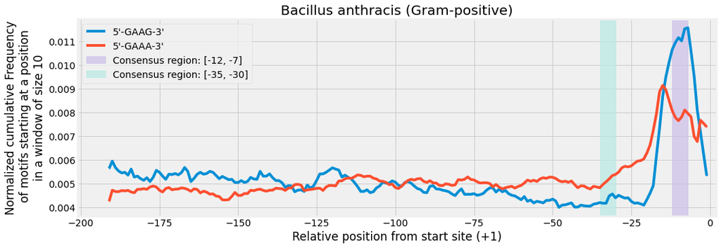

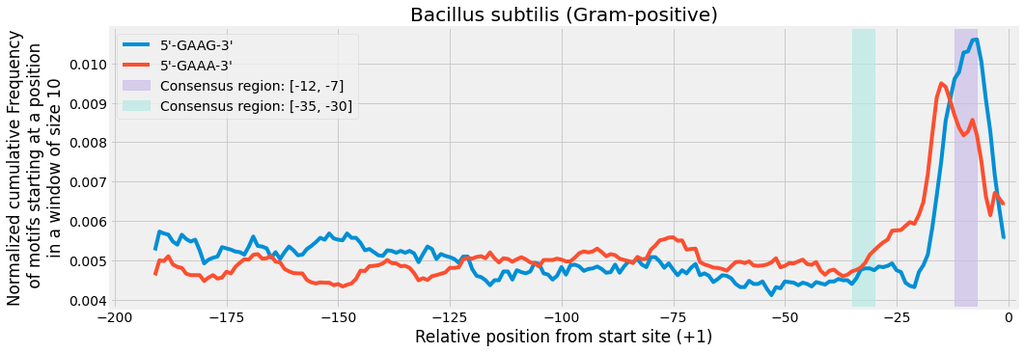

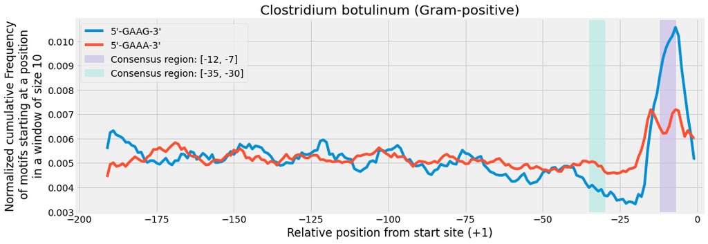

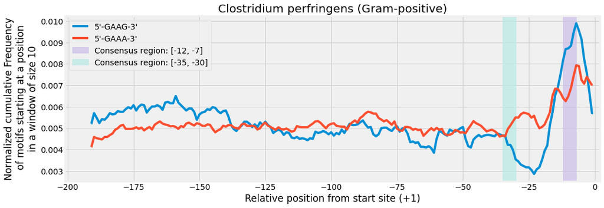

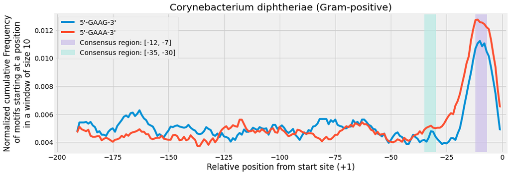

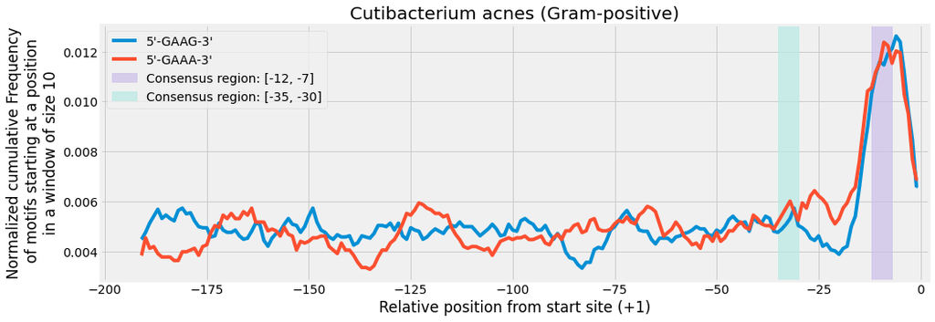

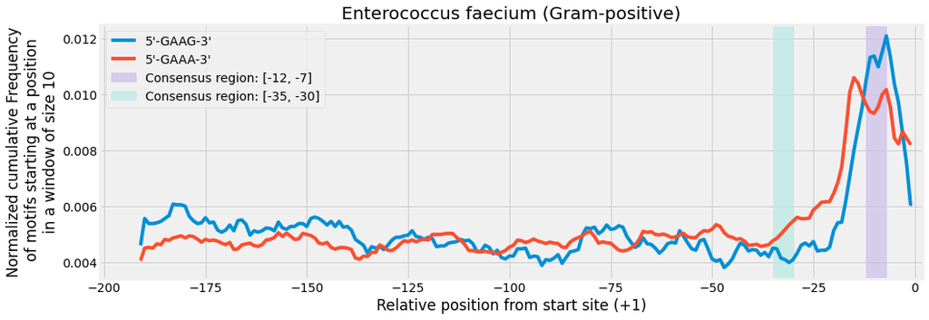

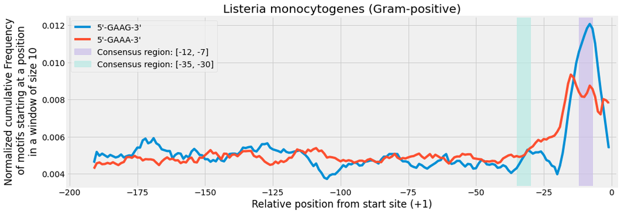

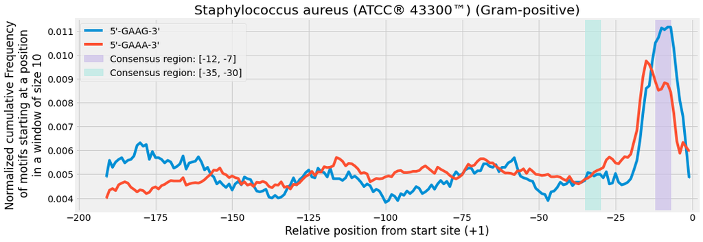

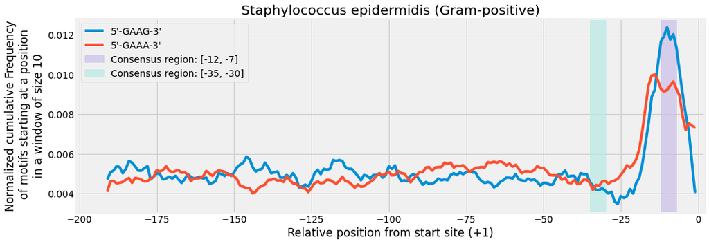

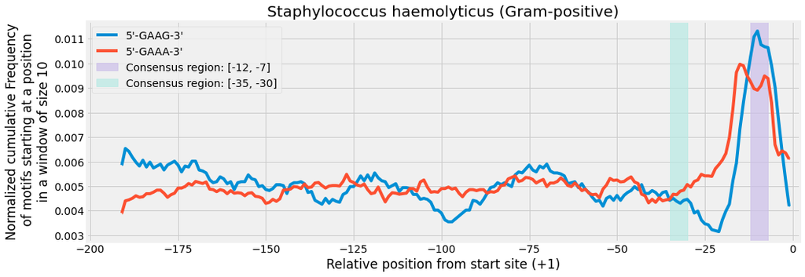

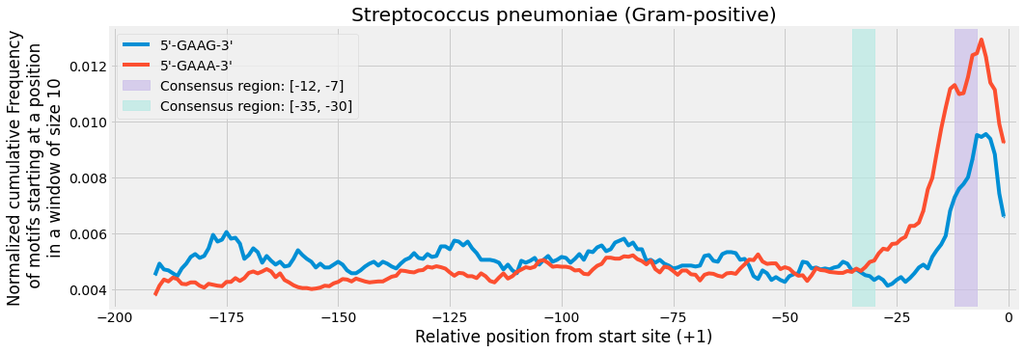